# EasyVisa

### Tuning with Gradient boosting with oversampled data

```python
# Define Gradient Boosting model
gbm = GradientBoostingClassifier(random_state=1)

# Define hyperparameter grid
param_grid = {
    'n_estimators': [50, 100, 150],
    'learning_rate': [0.01, 0.1, 1.0],
    'max_depth': [3, 5, 7]
}

# Setup GridSearchCV
grid_search_gbm = GridSearchCV(
    estimator=gbm,
    param_grid=param_grid,
    scoring='f1',
    cv=5,
    n_jobs=-1,
    verbose=1
)

# Fit the grid search on the oversampled training set
grid_search_gbm.fit(X_train_over, y_train_over)

# Print best parameters and best score
print("Best Parameters:", grid_search_gbm.best_params_)
print("Best F1 Score from CV:", grid_search_gbm.best_score_)
```

```
Fitting 5 folds for each of 27 candidates, totalling 135 fits
Best Parameters: {'learning_rate': 0.1, 'max_depth': 5, 'n_estimators': 50}
Best F1 Score from CV: 0.8104437805537807
```

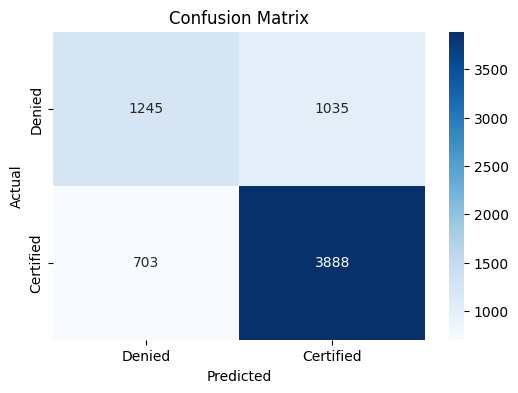

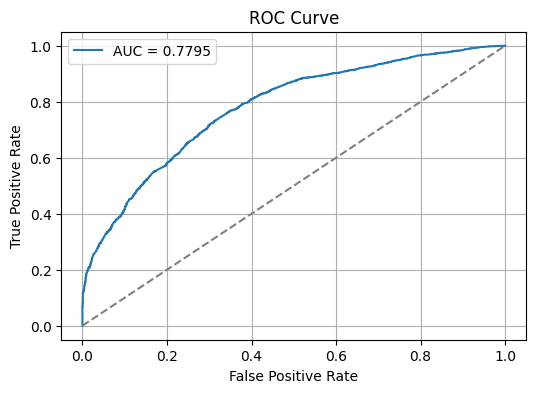

```python
# Get the best estimator from GridSearchCV
best_gbm = grid_search_gbm.best_estimator_

# Fit the best model on the oversampled training set again (optional but safe)
best_gbm.fit(X_train_over, y_train_over)

# Evaluate on validation set
# Confusion Matrix
plot_confusion_matrix(best_gbm, X_val, y_val, labels=["Denied", "Certified"])

# ROC Curve
plot_roc_curve(best_gbm, X_val, y_val)
```

Observations:

- True Positives (Certified correctly predicted): 3,888
- True Negatives (Denied correctly predicted): 1,245
- False Positives (Denied incorrectly predicted as Certified): 1,035
- False Negatives (Certified incorrectly predicted as Denied): 703

The model demonstrates a relatively balanced classification performance, with slightly fewer false negatives than false positives — indicating a mild preference toward predicting Certified outcomes.

Hyperparameter Tuning Impact: Best parameters:

- n_estimators = 50
- learning_rate = 0.1
- max_depth = 5

Model Performance Insight:

### Tuning XGBoost using oversampled data

```python
# Define the XGBoost model
xgb = XGBClassifier(random_state=1, use_label_encoder=False, eval_metric='logloss')

# Define hyperparameter grid
param_grid = {
    'n_estimators': [50, 100, 150],
    'learning_rate': [0.01, 0.1, 1.0],
    'max_depth': [3, 5, 7]
}

# Setup GridSearchCV
grid_search_xgb = GridSearchCV(
    estimator=xgb,
    param_grid=param_grid,
    scoring='f1',
    cv=5,
    n_jobs=-1,
    verbose=1
)

# Fit the grid search on the oversampled training set
grid_search_xgb.fit(X_train_over, y_train_over)

# Print best parameters and score
print("Best Parameters:", grid_search_xgb.best_params_)
print("Best F1 Score from CV:", grid_search_xgb.best_score_)
```

```
Fitting 5 folds for each of 27 candidates, totalling 135 fits
Best Parameters: {'learning_rate': 0.1, 'max_depth': 7, 'n_estimators': 50}
Best F1 Score from CV: 0.8119077885735646
```

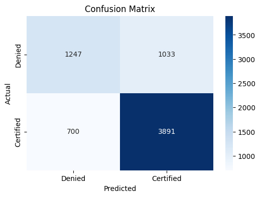

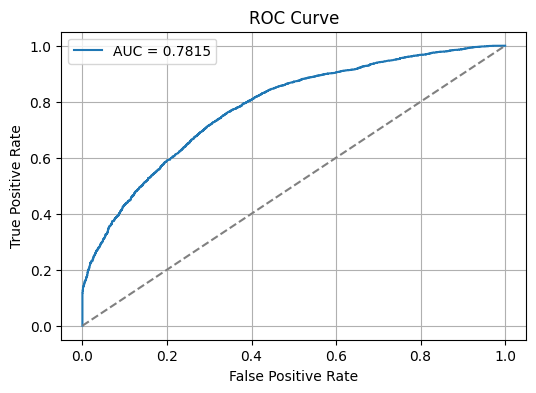

```python
# Get best model
best_xgb = grid_search_xgb.best_estimator_

# Fit best model again (optional but safe)
best_xgb.fit(X_train_over, y_train_over)

# Evaluate on validation set
plot_confusion_matrix(best_xgb, X_val, y_val, labels=["Denied", "Certified"])
plot_roc_curve(best_xgb, X_val, y_val)
```

Observations:

- True Positives (Certified correctly predicted): 3,891
- True Negatives (Denied correctly predicted): 1,247
- False Positives (Denied incorrectly predicted as Certified): 1,033
- False Negatives (Certified incorrectly predicted as Denied): 700

The tuned XGBoost model demonstrates balanced classification performance, correctly identifying a substantial number of both Certified and Denied cases.

The model demonstrates a relatively balanced classification performance, with slightly fewer false negatives than false positives — indicating a mild preference toward predicting Certified outcomes.

Hyperparameter Tuning Impact:

Best parameters found:

- n_estimators: 50
- learning_rate: 0.1
- max_depth: 7

These settings yielded the highest F1 Score during cross-validation: approximately 0.8119.

Model Performance Insight:

- The tuned XGBoost model achieves the highest F1 Score among all tuned models tested so far.
- This model may be ideal when both approval accuracy and rejection correctness are important, particularly in regulatory or compliance-heavy environments.

## Model performance comparison and choosing the final model

```python
# Predict on the test set
y_test_pred = best_xgb.predict(X_test)

# Print classification metrics
print(" Classification Report on Test Set:")
print(classification_report(y_test, y_test_pred, target_names=["Denied", "Certified"]))

# Accuracy
test_accuracy = accuracy_score(y_test, y_test_pred)
print(f" Accuracy on Test Set: {test_accuracy:.4f}")

# Confusion Matrix
print(" Confusion Matrix:")
print(confusion_matrix(y_test, y_test_pred))
```

```
 Classification Report on Test Set:
              precision    recall  f1-score   support

      Denied       0.61      0.47      0.53       254
   Certified       0.76      0.85      0.80       510

    accuracy                           0.72       764
   macro avg       0.69      0.66      0.67       764
weighted avg       0.71      0.72      0.71       764

 Accuracy on Test Set: 0.7238
 Confusion Matrix:
[[120 134]
 [ 77 433]]
```

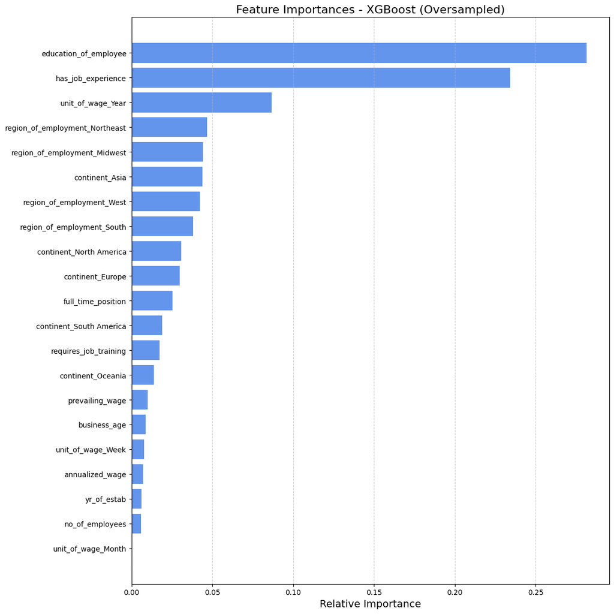

```python
# Get feature importances and names
feature_names = X_train.columns
importances = best_xgb.feature_importances_
indices = np.argsort(importances)

# Plot
plt.figure(figsize=(12, 12))
plt.title("Feature Importances - XGBoost (Oversampled)", fontsize=16)
plt.barh(range(len(indices)), importances[indices], color="cornflowerblue", align="center")
plt.yticks(range(len(indices)), [feature_names[i] for i in indices])
plt.xlabel("Relative Importance", fontsize=14)
plt.grid(True, axis='x', linestyle='--', alpha=0.6)
plt.tight_layout()
plt.show()
```

Demonstrate Feature Importance for XGBoost Classifier:

## Actionable Insights and Recommendations

**Insights**:

After training, tuning, and comparing multiple classifiers (including Random Forest, Gradient Boosting, AdaBoost, and XGBoost), the XGBoost model trained on oversampled data (via SMOTE) achieved the best performance:

Key Predictive Features (from XGBoost)

Impact of Oversampling

SMOTE (Synthetic Minority Oversampling Technique) improved model performance on imbalanced data.

- All models trained on oversampled data had higher F1 scores than those on undersampled or original data.
- Particularly effective for models like XGBoost and Gradient Boosting.

Confusion Matrix Observations

**Recommendations**:

1. Deploy XGBoost Model Use the tuned XGBoost model with oversampled data for production predictions.

Integrate into an internal visa analytics dashboard or candidate profiling system.

2. Feature-Driven Application Strategy Use feature importance to guide visa applicants:
- Encourage candidates to pursue advanced degrees (e.g., Master’s, Doctorate).
- Target employment in regions with higher approval rates.
- Consider wage negotiations that exceed prevailing wage standards.
- Highlight relevant job experience in applications.

```python
!pip install nbconvert
```

```python
notebook_filename = "EasyVisa.ipynb"  # Change this to match your notebook name
```

```python
!jupyter nbconvert --to html "EasyVisa.ipynb"
```

[output not shown]

[output cut: 136 more lines]

[output not shown]